# Tutorial 3: ANOVA

Ziling Ma

October 30th, 2024

## Introduction

Analysis of variance (ANOVA), in its simplest form, is used to compare multiple means in a test for equivalence. In that sense, it’s a straightforward extension of the hypothesis test comparing two means. It determines whether there are any statistically significant differences among the means of the groups. ANOVA is an extension of the t-test, which is used to compare means between two groups only.

In ANOVA, the variation in the data is partitioned into two components: the variation between groups and the variation within groups. If the variation between groups is significantly larger than the variation within groups, it suggests that there are differences among the group means.

### The Hypotheses

The hypotheses in ANOVA are as follows:

- Null Hypothesis ($H_0$): There are no significant differences among the group means.
  $$H_0\: :\: \mu_1 = \mu_2=\cdots =
  \mu_k$$
- Alternative Hypothesis ($H_1$): At least one group mean is significantly different from the others.
  $$H_1 \: \mu_1,\mu_2,\cdots,\mu_k\: \text{are
  not all equal}$$
  In fact, when $k=2$, the two-sample t-test is equivalent to ANOVA; for that reason, ANOVA is most frequently employed when $k > 2$.

### Assumptions

ANOVA relies on the following assumptions:

1. Independence: The observations within each group are independent of each other.
2. Normality: The data within each group are normally distributed.
3. Homogeneity of variances: The variances within each group are equal.

If the assumptions of equality of variances or normality are violated, it doesn’t necessarily mean your results will be completely worthless, but it will impact the overall effectiveness of detecting a true difference in the means.

Alternative statistical tests or transformations of the data may be more appropriate.

It’s also worth noting that you don’t need to have an equal number of observations in each group to perform the test (in which case it is referred to as unbalanced). However, having unbalanced groups does render the test more sensitive to potentially detrimental effects if your assumptions of equal- ity of variances and normality are not sound.

### Types of ANOVA

There are different types of ANOVA based on the experimental design and the number of factors involved:

1. One-Way ANOVA: Compares means across one categorical independent variable (factor) with two or more levels (groups).

Example

Suppose you are testing whether different teaching methods (Method A, Method B, Method C) result in different student performance. The factor would be the teaching method, and the dependent variable would be student scores.

Hypotheses:

Null Hypothesis ($H_0$): The means of all groups are equal (no difference).

Alternative Hypothesis ($H_1$): At least one group mean is different from the others.

2. Two-Way ANOVA: Compares means across two categorical independent variables (factors) simultaneously to examine their main effects and interaction effect.

Example

Suppose you want to test whether different teaching methods (Method A, Method B, Method C) and different study environments (Quiet, Noisy) affect student performance. The two factors are the teaching method and the study environment, and the dependent variable is student scores.

Main Effects:

1. The individual effect of each factor on the dependent variable (e.g., effect of teaching method, effect of study environment).
2. Interaction Effect: Examines whether the effect of one factor depends on the level of the other factor (e.g., does the teaching method work differently in noisy and quiet environments?).

Hypotheses:

1. Main effect for Factor A (e.g., teaching method):

Null Hypothesis ($H_0$): There is no effect of Factor A (means are equal across levels of Factor A).

Alternative Hypothesis ($H_1$): There is a significant effect of Factor A.

2. Main effect for Factor B (e.g., study environment):

Null Hypothesis ($H_0$): There is no effect of Factor B.

Alternative Hypothesis ($H_1$): There is a significant effect of Factor B.

3. Interaction effect between Factor A and Factor B:

Null Hypothesis ($H_0$): There is no interaction between Factor A and Factor B.

Alternative Hypothesis ($H_1$): There is a significant interaction effect.

3. Repeated Measures ANOVA: Compares means across one categorical independent variable (factor) with repeated measurements over time or conditions on the same subjects.
4. Mixed Effects ANOVA: Similar to repeated measures ANOVA, but includes both fixed and random effects in the model.
5. MANOVA: Multivariate Analysis of Variance compares means across two or more dependent variables simultaneously.

### Performing ANOVA in R

In R, you can perform ANOVA using the `aov()` function for most types of ANOVA. Here’s a general syntax:

```
result <- aov(response_variable ~ factor1 + factor2 + ..., data = your_data)
summary(result)
```

- `response_variable` is the numerical variable you want to analyze.
- `factor1`, `factor2`, etc., are the categorical independent variables (factors) you want to include in the analysis.
- `your_data` is the name of your dataset.

The `aov()` function performs the ANOVA analysis, and the `summary()` function provides the ANOVA table and other useful statistics.

### Interpreting the Results

The output of ANOVA includes several statistics, such as the F-value, $p$-value, and degrees of freedom. The key information to interpret is:

- The F-value: Indicates the overall significance of the model. A larger F-value suggests stronger evidence against the null hypothesis.
- The $p$-value: Indicates the probability of obtaining the observed result by chance. If the $p$-value is below a chosen significance level (e.g., 0.05), the null hypothesis is rejected, and it can be concluded that there are significant differences among the group means.
- Degrees of freedom (DF): Represent the number of independent pieces of information available in the data.

## Examples

### Example 1: One-Way ANOVA

```r
# Create a data frame with heights
data <- data.frame(
  City = rep(c("A", "B", "C"), each = 10),
  Height = c(170, 175, 180, 165, 172, 168, 173, 169, 171, 175,
             160, 165, 170, 155, 162, 158, 163, 159, 161, 165,
             180, 185, 190, 175, 182, 178, 183, 179, 181, 185)
)
```

### Example 2: Two-Way ANOVA

```r
# Create a data frame with weights
data <- data.frame(
  Treatment = rep(c("A", "B", "C", "D"), each = 25),
  Gender = rep(c("Male", "Female"), times = 50),
  Weight = c(70, 75, 80, 85, 90, 65, 70, 75, 80, 85,
             60, 65, 70, 75, 80, 55, 60, 65, 70, 75,
             75, 80, 85, 90, 95, 70, 75, 80, 85, 90,
             65, 70, 75, 80, 85, 60, 65, 70, 75, 80,
             80, 85, 90, 95, 100, 75, 80, 85, 90, 95,
             70, 75, 80, 85, 90, 65, 70, 75, 80, 85,
             85, 90, 95, 100, 105, 80, 85, 90, 95, 100,
             75, 80, 85, 90, 95, 70, 75, 80, 85, 90,
             90, 95, 100, 105, 110, 85, 90, 95, 100, 105,
             80, 85, 90, 95, 100, 75, 80, 85, 90, 95)
)
```

## Explanation: Hypotheses and Diagnostic Checking

Let’s use the ‘chickwts’ data for the example—the weights of chicks based on $k = 6$ different feeds. You’re interested in comparing the mean weights according to feed type to see whether they’re all equal.

1. In the first step, we load the’chickwts’ data from the R library ‘datasets’.

```r
data("chickwts")
```

$$H_0:
\mu_{\text{casein}}=\mu_{\text{horsebean}}=\mu_{\text{linseed}}=\mu_{\text{meatmeal}}=\mu_{\text{soybean}}=\mu_{\text{sunflower}}$$
$$H_1 : \text{The means are not all
equal.}$$

Assuming independence of the data, before implementing the test, you must first check that the other assumptions are valid.

To test for equality of variances, you can use Levene’s test. In R, you can use function `leveneTest()` in R library `car`.

The Null hypothesis $H_0$: The variances are equal across the groups.

The Alternative hypothesis $H_1$: The variances are not equal across the groups.

If the $p$-value from Levene’s test is small (usually below $0.05$), it suggests that the variances across the groups are significantly different, indicating heteroscedasticity.

```r
library(car)
leveneTest(chickwts$weight~chickwts$feed)
```

```
## Levene's Test for Homogeneity of Variance (center = median)
##       Df F value Pr(>F)
## group  5  0.7493 0.5896
##       65
```

The output shows the $F$-statistic, degrees of freedom, and the $p$-value $(\text{Pr}(>F))$.

The $p$-value is 0.5896, which is greater than the common threshold of 0.05. This means you fail to reject the null hypothesis. In other words, the variances across the groups are not significantly different, indicating homogeneity of variance.

Next, consider the assumption of normality of the raw observations.

To test normality, we perform a Shapiro-Wilk test. We can use the `shapiro.test()` function to test the residuals for normality.

Null Hypothesis $H_0$: The data is normally distributed. Alternative Hypothesis $H_1$: The data is not normally distributed.

If the p-value is greater than the significance level (usually 0.05), we fail to reject the null hypothesis, indicating that the data is normally distributed. Conversely, if the p-value is less than the significance level, the data is not normally distributed.

Since we need to test the normality using residuals, we perform the ANOVA and then extract the residuals

```r
# Perform ANOVA
anova_model <- aov(weight ~ feed, data = chickwts)
summary(anova_model)
```

```
##             Df Sum Sq Mean Sq F value   Pr(>F)
## feed         5 231129   46226   15.37 5.94e-10 ***
## Residuals   65 195556    3009
## ---
## Signif. codes:  0 '***' 0.001 '**' 0.01 '*' 0.05 '.' 0.1 ' ' 1
```

```r
# Extract residuals
residuals_anova <- residuals(anova_model)

# Perform Shapiro-Wilk test for normality of residuals
shapiro.test(residuals_anova)
```

```
##
##  Shapiro-Wilk normality test
##
## data:  residuals_anova
## W = 0.98616, p-value = 0.6272
```

Interpretation of the Shapiro-Wilk Test Result:

W = 0.98616: This is the Shapiro-Wilk test statistic. It indicates how closely the distribution of residuals aligns with a normal distribution (closer to 1 means a better fit to normality).

p-value = 0.6272: Since the p-value is greater than 0.05, you fail to reject the null hypothesis. This means that the residuals of your ANOVA model are not significantly different from a normal distribution, which satisfies the normality assumption required for ANOVA.

Meanwhile, you can also consider to plot `Q-Q plot` for residuals

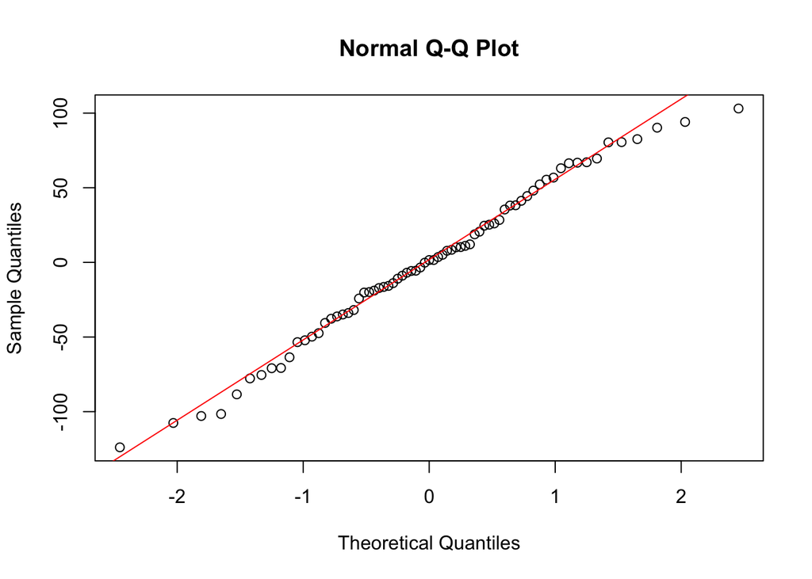

```r
qqnorm(residuals_anova)
qqline(residuals_anova, col = "red")
```

If the residuals are normally distributed, the points should fall approximately along the diagonal line (which is added using the `qqline()` function). From this Q-Q plot, the residuals of our model appear to be normally distributed, which supports the normality assumption of ANOVA.

If ANOVA indicates significant differences among the group means, post hoc tests can be conducted to determine which specific groups differ from each other. Common post hoc tests include Tukey’s Honestly Significant Difference (HSD), Bonferroni correction, and Dunnett’s test. These post hoc tests adjust for multiple comparisons and provide pairwise comparisons between groups.

## Exercises

### Exercise 1

For this exercise we use the dataset `InsectSprays`, which is available in `R`. In this experiment, 6 different insecticides were used and the number of dead insects in each plot were counted. There were 12 replications for each treatment level (insecticide), for a total of 72 observations.

#### Part 3

1. Draw a boxplot for the results and add axes labels and a title. Add the points for each treatment level. Observe that there is overplotting. Add some noise in the horizontal direction to avoid this problem. Comment on what you observe.

```r
attach(InsectSprays)
```

2. Do an analysis of variance and test whether the different insecticides have an effect. Use level $\alpha = 0.01$ for this test. What are your conclusions?
3. What are the estimated values for the average values for the six treatments $\hat\mu + \hat\tau_i$, $i = 1, \dots, 6$? What are the estimated values for the effects $\hat\tau_i$, $i = 1,\dots, 6$?

4. What is the estimated value for the variance and standard deviation of the experimental error $\sigma^2$?

5. Make residual plots for checking assumptions. Do you think the usual assumptions for the model are reasonable in this experiment?
6. Use Levene’s test for equal variances and Shapiro-Wilk for normality using this model and comment on your results.

#### Part 4

7. Consider an alternative model using the square root of the number of counts. Obtain the analysis of variance table and compare with the previous model.
8. Draw the diagnostic plots for this model and comment.
9. Again, use Levene’s tests and Shapiro-Wilk and comment on your results.
10. Which non-parametric test can be applied in this situation? What are the assumptions of the test? Do this test and compare with the results you obtained previously.

### Exercise 2

For this exercise we will use the data set `ToothGrowth`.

#### Part 5

1. Explore the data in `ToothGrowth`.

```r
str(ToothGrowth)
```

```
## 'data.frame':    60 obs. of  3 variables:
##  $ len : num  4.2 11.5 7.3 5.8 6.4 10 11.2 11.2 5.2 7 ...
##  $ supp: Factor w/ 2 levels "OJ","VC": 2 2 2 2 2 2 2 2 2 2 ...
##  $ dose: num  0.5 0.5 0.5 0.5 0.5 0.5 0.5 0.5 0.5 0.5 ...
```

```r
head(ToothGrowth)
```

```
##    len supp dose
## 1  4.2   VC  0.5
## 2 11.5   VC  0.5
## 3  7.3   VC  0.5
## 4  5.8   VC  0.5
## 5  6.4   VC  0.5
## 6 10.0   VC  0.5
```

```r
psych::describe(ToothGrowth)
```

```
##       vars  n  mean   sd median trimmed  mad min  max range  skew kurtosis   se
## len      1 60 18.81 7.65  19.25   18.95 9.04 4.2 33.9  29.7 -0.14    -1.04 0.99
## supp*    2 60  1.50 0.50   1.50    1.50 0.74 1.0  2.0   1.0  0.00    -2.03 0.07
## dose     3 60  1.17 0.63   1.00    1.15 0.74 0.5  2.0   1.5  0.37    -1.55 0.08
```

2. `dose` is a numerical variable and we would like it to be categorical. Transform it to a factor. Make sure to preserve the order.
3. Do a boxplot with the following command and comment on the result.

```
boxplot(len ~ supp * dose, data=ToothGrowth)
```

4. Use `interaction.plot()` to explore possible interactions between the factors. Comment.

```
interaction.plot(x.factor=dose, trace.factor=supp,
                 response=len, fun=mean, type='b')
```

5. Use `lm()` to build and analyze a two-way model.

#### Part 6

6. Use `aov()` to build and analyze a two-way model.
7. Plot the diagnostics graphs and comment on the results.
8. Use `TukeyHSD()` with the option `which = c('dose')`. Comment.
9. Fit a model without interactions using lm and compare with the complete model using anova. What is your conclusion?
10. Fit a model only with interactions and compare with the full model. What is your conclusion?